# Click Prediction (WNS Analytics Wizard 2019)

Anushree Tomar

# Import Required Libraries

```r
library(data.table)
library(DataExplorer)
library(caret)
library(dplyr)
library(lubridate)
library(h2o)
```

# Reading files

First read all files in the train and test folder

```r
train<-fread("train_NA17Sgz\\train.csv")
view_log<-fread("train_NA17Sgz\\view_log.csv")
item_data<-fread("train_NA17Sgz\\item_data.csv")
test<-fread("test_aq1FGdB\\test.csv")
```

# Observing Data

Here we will observe the data in train folder

```r
head(train)
```

```
                      impression_id     impression_time user_id app_code   os_version is_4G is_click
1: c4ca4238a0b923820dcc509a6f75849b 2018-11-15 00:00:00   87862      422          old     0        0
2: 45c48cce2e2d7fbdea1afc51c7c6ad26 2018-11-15 00:01:00   63410      467       latest     1        1
3: 70efdf2ec9b086079795c442636b55fb 2018-11-15 00:02:00   71748      259 intermediate     1        0
4: 8e296a067a37563370ded05f5a3bf3ec 2018-11-15 00:02:00   69209      244       latest     1        0
5: 182be0c5cdcd5072bb1864cdee4d3d6e 2018-11-15 00:02:00   62873      473       latest     0        0
6: 3416a75f4cea9109507cacd8e2f2aefc 2018-11-15 00:03:00   67352      409       latest     1        0
```

In the train data Add impression id are given with their impression time,user_id,Application Code for a partner website where the ad was shown and information of Whether user clicked the AD or not are given.

```r
head(item_data)
```

```
   item_id item_price category_1 category_2 category_3 product_type
1:   26880       4602         11         35         20         3040
2:   54939       3513         12         57         85         6822
3:   40383        825         17          8        279         1619
4:    8777       2355         13         58        189         5264
5:  113705       1267         17         39        151        10239
6:  108843        953          9          9         90          703
```

In the item_data type and price of product are given with category depth and item id.

```r
head(view_log)
```

```
           server_time device_type session_id user_id item_id
1: 2018-10-15 08:58:00     android     112333    4557   32970
2: 2018-10-15 08:58:00     android     503590   74788    7640
3: 2018-10-15 08:58:00     android     573960   23628  128855
4: 2018-10-15 08:58:00     android     121691    2430   12774
5: 2018-10-15 08:58:00     android     218564   19227   28296
6: 2018-10-15 08:58:00     android     635314   87387   86660
```

In view_log data server log of users and items are given with their id’s.

```r
head(test)
```

```
                      impression_id     impression_time user_id app_code os_version is_4G
1: a9e7126a585a69a32bc7414e9d0c0ada 2018-12-13 07:44:00   44754      127     latest     1
2: caac14a5bf2ba283db7708bb34855760 2018-12-13 07:45:00   29656       44     latest     0
3: 13f10ba306a19ce7bec2f3cae507b698 2018-12-13 07:46:00   25234      296     latest     1
4: 39c4b4dc0e9701b55a0a4f072008fb3f 2018-12-13 07:47:00   22988      207     latest     1
5: bf5a572cca75f5fc67f4b14e58b11d70 2018-12-13 07:48:00   35431      242     latest     1
6: ca09514449e304fee91456fb0918667a 2018-12-13 07:48:00     489      207     latest     0
```

Test data has similar features as train data.

# Check for user_id in train and test

```r
trainuid<-as.data.frame(table(train$user_id))
testuid<-as.data.frame(table(test$user_id))
trainuid$Var1<-as.character(trainuid$Var1)
testuid$Var1<-as.character(testuid$Var1)
matchuid<-semi_join(trainuid,testuid,by="Var1")
non_matched<-as.data.frame(anti_join(trainuid,testuid,by="Var1"))
```

There are different-different users in both train and test files. So we will not consider this variable in model building.

# Check for missing value

```r
introduce(train)
```

```
     rows columns discrete_columns continuous_columns all_missing_columns total_missing_values
1: 237609       7                3                  4                   0                    0
   complete_rows total_observations memory_usage
1:        237609            1663263     35234256
```

```r
introduce(test)
```

```
    rows columns discrete_columns continuous_columns all_missing_columns total_missing_values
1: 90675       6                3                  3                   0                    0
   complete_rows total_observations memory_usage
1:         90675             544050     12742304
```

```r
introduce(view_log)
```

```
      rows columns discrete_columns continuous_columns all_missing_columns total_missing_values
1: 3118622       5                2                  3                   0                    0
   complete_rows total_observations memory_usage
1:       3118622           15593110     93950744
```

```r
introduce(item_data)
```

```
     rows columns discrete_columns continuous_columns all_missing_columns total_missing_values
1: 132761       6                0                  6                   0                    0
   complete_rows total_observations memory_usage
1:        132761             796566      3188440
```

All data has no missing value.

# Merge Data

At first we merge the view_log files with the item_data for analysis.

```r
introduce(newdata)
```

```
      rows columns discrete_columns continuous_columns all_missing_columns total_missing_values
1: 3118622      10                2                  8                   0                 8910
   complete_rows total_observations memory_usage
1:       3116840           31186220    156324528
```

```r
head(newdata)
```

```
   item_id         server_time device_type session_id user_id item_price category_1 category_2
1:       0 2018-10-22 19:17:00     android      95432   40223       2873         14         61
2:       0 2018-11-13 04:35:00     android    1071604   22297       2873         14         61
3:       1 2018-10-16 11:53:00     android     245485    1173       1360         11         51
4:       1 2018-11-13 20:28:00     android     388486   20876       1360         11         51
5:       2 2018-10-16 08:42:00     android     875577   44438      22192          8         41
6:       2 2018-10-31 13:22:00     android     360700   92016      22192          8         41
   category_3 product_type
1:        132         2398
2:        132         2398
3:        329         3999
4:        329         3999
5:         36          251
6:         36          251
```

```r
apply(newdata,2,function(x){sum(is.na(x))})
```

```
     item_id  server_time  device_type   session_id      user_id   item_price   category_1   category_2
           0            0            0            0            0         1782         1782         1782
  category_3 product_type
        1782         1782
```

```r
newdata[which(is.na(newdata$item_price))]
```

```
      item_id         server_time device_type session_id user_id item_price category_1 category_2
   1:     873 2018-10-21 16:17:00     android     457461   57795         NA         NA         NA
   2:     873 2018-10-21 16:20:00     android     457461   57795         NA         NA         NA
   3:     873 2018-10-23 08:57:00     android     585125   14885         NA         NA         NA
   4:     873 2018-10-24 21:26:00     android     936733     699         NA         NA         NA
   5:     873 2018-10-28 09:22:00     android     179015     699         NA         NA         NA
  ---
1778:  132148 2018-10-18 10:20:00     android     842121   22258         NA         NA         NA
1779:  132148 2018-12-07 19:01:00     android      50872   48110         NA         NA         NA
1780:  132148 2018-12-07 19:02:00     android      50872   48110         NA         NA         NA
1781:  132148 2018-12-07 19:03:00     android      50872   48110         NA         NA         NA
1782:  132645 2018-11-10 17:19:00     android     154715   53164         NA         NA         NA
      category_3 product_type
   1:         NA           NA
   2:         NA           NA
   3:         NA           NA
   4:         NA           NA
   5:         NA           NA
  ---
1778:         NA           NA
1779:         NA           NA
1780:         NA           NA
1781:         NA           NA
1782:         NA           NA
```

As you can see that there are 1782 records where price of item, category depth and product type are missing.

# Check proportion of target variable

```r
print("Proportion of target variable in train data")
```

```
[1] "Proportion of target variable in train data"
```

```r
prop.table(table(train[,is_click]))*100
```

```
        0         1
95.428624  4.571376
```

# Percent distribution of click

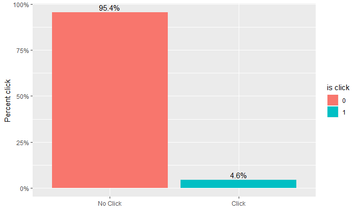

```r
ggplot(train, aes(x = factor(is_click))) +
  geom_bar(aes(y = (..count..)/sum(..count..),fill=factor(is_click))) +
  geom_text(aes(y = ((..count..)/sum(..count..)), label = scales::percent((..count..)/sum(..count..))), stat = "count",   vjust = -0.3) + scale_y_continuous(labels = percent)+scale_x_discrete(labels=c("0"="No Click","1"="Click"))+  labs(x=" ",y = "Percent click",fill="is click")
```

There are only 4.6% of users clicking the ad which is shown to them on the partner websites.

# Percent distribution of click by network

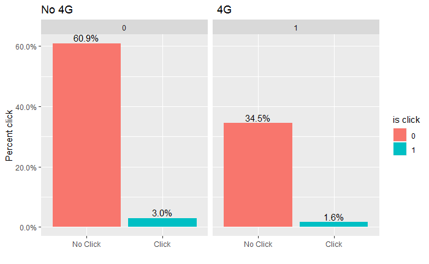

```r
ggplot(train, aes(x = factor(is_click))) +
  geom_bar(aes(y = (..count..)/sum(..count..),fill=factor(is_click))) +
  geom_text(aes(y = ((..count..)/sum(..count..)), label = scales::percent((..count..)/sum(..count..))), stat = "count",   vjust = -0.3) + scale_y_continuous(labels = percent)+scale_x_discrete(labels=c("0"="No Click","1"="Click"))+facet_wrap(~is_4G)+
  labs(title ="No 4G                                               4G", x=" ",y = "Percent click",fill="is click")
```

```r
NA
```

From the above graph we can see that 3.0% of users clicking the add not having 4G network.

# Percent distribution of click by OS version

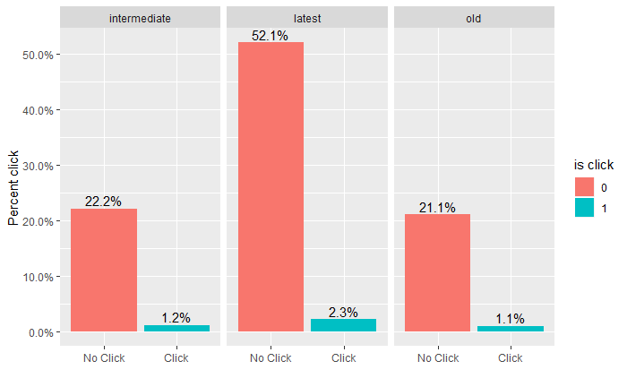

```r
ggplot(train, aes(x = factor(is_click))) +
  geom_bar(aes(y = (..count..)/sum(..count..),fill=factor(is_click))) +
  geom_text(aes(y = ((..count..)/sum(..count..)), label = scales::percent((..count..)/sum(..count..))), stat = "count",   vjust = -0.3) + scale_y_continuous(labels = percent)+scale_x_discrete(labels=c("0"="No Click","1"="Click"))+facet_wrap(~os_version)+
  labs(x=" ",y = "Percent click",fill="is click")
```

```r
NA
```

2.3% of users using latest os version.

# Analyse Frequently clicked Application code

```r
head(appcode)
```

```
    appcode Freq
95      190  741
175     371  687
64      127  577
140     296  574
116     244  539
104     207  482
```

Above data is showing top 6 most frequently clicked application code for a partner website where the ad was shown.

# Data type of variables

```r
str(train)
```

```
Classes ‘data.table’ and 'data.frame':  237609 obs. of  7 variables:
 $ impression_id  : chr  "c4ca4238a0b923820dcc509a6f75849b" "45c48cce2e2d7fbdea1afc51c7c6ad26" "70efdf2ec9b086079795c442636b55fb" "8e296a067a37563370ded05f5a3bf3ec" ...
 $ impression_time: chr  "2018-11-15 00:00:00" "2018-11-15 00:01:00" "2018-11-15 00:02:00" "2018-11-15 00:02:00" ...
 $ user_id        : int  87862 63410 71748 69209 62873 67352 64356 27329 83318 70206 ...
 $ app_code       : int  422 467 259 244 473 409 190 481 386 190 ...
 $ os_version     : chr  "old" "latest" "intermediate" "latest" ...
 $ is_4G          : int  0 1 1 1 0 1 0 0 0 0 ...
 $ is_click       : int  0 1 0 0 0 0 0 0 0 0 ...
 - attr(*, ".internal.selfref")=<externalptr>
 - attr(*, "index")= int
  ..- attr(*, "__is_click")= int  1 3 4 5 6 7 8 9 10 12 ...
```

# Convert “impression_time” into date time

```r
test$impression_time<-ymd_hms(test$impression_time)
train$impression_time<-ymd_hms(train$impression_time)
```

# Extract year,month,day,hour,min and seconds from date

```r
#Process test data
test<-test[,c("I_min","I_sec","I_mon","I_wday","I_hour","I_yr"):=list(minute(impression_time),second(impression_time),months(impression_time), wday(impression_time), data.table::hour(impression_time), data.table::year(impression_time))]
#process train data
train<-train[,c("I_min","I_sec","I_mon","I_wday","I_hour","I_yr"):=list(minute(impression_time),second(impression_time),months(impression_time), wday(impression_time), data.table::hour(impression_time), data.table::year(impression_time))]
```

# Convert Character variable to factor

```r
test[,c("impression_id","user_id","app_code" ,"os_version","is_4G","I_mon","I_wday","I_yr" )]<-lapply(test[,c("impression_id","user_id","app_code" ,"os_version","is_4G" ,"I_mon","I_wday","I_yr")], as.factor)
train[,c("impression_id","user_id","app_code","os_version","is_4G","I_mon","I_wday","I_yr","is_click")]<-lapply(train[,c("impression_id","user_id","app_code" ,"os_version","is_4G","I_mon","I_wday","I_yr","is_click")], as.factor)
```

# Percent distribution of click by month

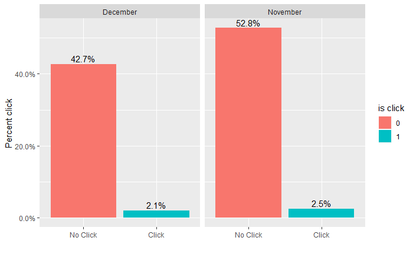

```r
ggplot(train, aes(x = is_click)) +
  geom_bar(aes(y = (..count..)/sum(..count..),fill=is_click)) +
  geom_text(aes(y = ((..count..)/sum(..count..)), label = scales::percent((..count..)/sum(..count..))), stat = "count",   vjust = -0.3) + scale_y_continuous(labels = percent)+scale_x_discrete(labels=c("0"="No Click","1"="Click"))+facet_wrap(~I_mon)+
  labs(x=" ",y = "Percent click",fill="is click")
```

```r
NA
```

# Percent distribution of click by weekdays

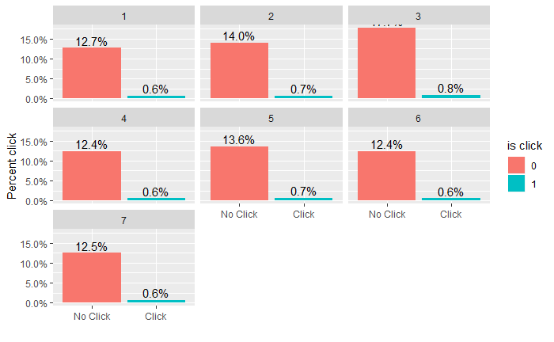

```r
ggplot(train, aes(x = is_click)) +
  geom_bar(aes(y = (..count..)/sum(..count..),fill=is_click)) +
  geom_text(aes(y = ((..count..)/sum(..count..)), label = scales::percent((..count..)/sum(..count..))), stat = "count",   vjust = -0.3) + scale_y_continuous(labels = percent)+scale_x_discrete(labels=c("0"="No Click","1"="Click"))+facet_wrap(~I_wday)+
  labs(x=" ",y = "Percent click",fill="is click")
```

```r
NA
```

# Remove variable

we will remove “impression_id”,“impression_time”,“user_id”,“app_code”,“I_sec”,“I_yr” from test and train data

```r
label<-test$impression_id
test[,c("impression_id","impression_time","user_id","app_code","I_sec","I_yr"):=NULL]
train[,c("impression_id","impression_time","user_id","app_code","I_sec","I_yr"):=NULL]
```

# Data Partition for model building

Perform 50-50 split

```r
trainindex<-createDataPartition(train$is_click,p=0.5,list=F)
traindata<-train[trainindex,]
testdata<-train[-trainindex,]
```

# Model buliding with h2o

Initialize Connection

nthreads is used to specify the number of threads. -1 denotes all available cores can be used.

```r
h2o.init(nthreads = -1)
```

```
H2O is not running yet, starting it now...

Note:  In case of errors look at the following log files:
    C:\Users\Anushree\AppData\Local\Temp\RtmpEHldBm/h2o_Anushree_started_from_r.out
    C:\Users\Anushree\AppData\Local\Temp\RtmpEHldBm/h2o_Anushree_started_from_r.err

java version "1.8.0_162"
Java(TM) SE Runtime Environment (build 1.8.0_162-b12)
Java HotSpot(TM) 64-Bit Server VM (build 25.162-b12, mixed mode)

Starting H2O JVM and connecting: .. Connection successful!

R is connected to the H2O cluster:
    H2O cluster uptime:         10 seconds 576 milliseconds
    H2O cluster timezone:       Asia/Kolkata
    H2O data parsing timezone:  UTC
    H2O cluster version:        3.26.0.2
    H2O cluster version age:    1 month and 5 days
    H2O cluster name:           H2O_started_from_R_Anushree_bfx515
    H2O cluster total nodes:    1
    H2O cluster total memory:   1.75 GB
    H2O cluster total cores:    0
    H2O cluster allowed cores:  0
    H2O cluster healthy:        TRUE
    H2O Connection ip:          localhost
    H2O Connection port:        54321
    H2O Connection proxy:       NA
    H2O Internal Security:      FALSE
    H2O API Extensions:         Amazon S3, Algos, AutoML, Core V3, Core V4
    R Version:                  R version 3.5.0 (2018-04-23)
```

# Convert Data into h2o format

```r
trainh2o <- as.h2o(traindata)
testh2o <- as.h2o(testdata)

#set variables
y <- "is_click"
x <- setdiff(colnames(trainh2o),y)
```

# Model random Forest

```r
DRF <- h2o.randomForest(x = x, y = y,
                        training_frame = trainh2o,
                        validation_frame = testh2o,
                        keep_cross_validation_models = TRUE,
                        balance_classes = F,
                        model_id = "myDRF",
                        nfolds=5,
                        max_depth = 20,
                        ntrees = 100)
```

# Prediction on test data

```r
h2o.performance (DRF,xval = T)
```

```
H2OBinomialMetrics: drf
** Reported on cross-validation data. **
** 5-fold cross-validation on training data (Metrics computed for combined holdout predictions) **

MSE:  0.04677646
RMSE:  0.2162787
LogLoss:  0.2023219
Mean Per-Class Error:  0.490159
AUC:  0.510452
pr_auc:  0.04650836
Gini:  0.02090409
R^2:  -0.07226852

Confusion Matrix (vertical: actual; across: predicted) for F1-optimal threshold:
           0     1    Error           Rate
0      37135 76239 0.672456  =76239/113374
1       1672  3759 0.307862     =1672/5431
Totals 38807 79998 0.655789  =77911/118805

Maximum Metrics: Maximum metrics at their respective thresholds
                        metric threshold    value idx
1                       max f1  0.022781 0.088003 358
2                       max f2  0.011795 0.193266 395
3                 max f0point5  0.029788 0.057957 333
4                 max accuracy  0.576674 0.954278   0
5                max precision  0.385208 0.051672  27
6                   max recall  0.008544 1.000000 399
7              max specificity  0.576674 0.999991   0
8             max absolute_mcc  0.022781 0.008765 358
9   max min_per_class_accuracy  0.028289 0.508378 338
10 max mean_per_class_accuracy  0.022781 0.509841 358

Gains/Lift Table: Extract with `h2o.gainsLift(<model>, <data>)` or `h2o.gainsLift(<model>, valid=<T/F>, xval=<T/F>)`
```

```r
test_prediction_new = h2o.predict(DRF, newdata = testh2o)
```

# Model Evaluation on test data

```r
predDRF<-as.data.frame(test_prediction_new)
confusionMatrix(factor(testdata$is_click),factor(predDRF$predict),mode = "everything",positive = "1")
```

```
Confusion Matrix and Statistics

          Reference
Prediction     0     1
         0 13733 99640
         1   604  4827

               Accuracy : 0.1562
                 95% CI : (0.1542, 0.1583)
    No Information Rate : 0.8793
    P-Value [Acc > NIR] : 1

                  Kappa : 0.001

 Mcnemar's Test P-Value : <2e-16

            Sensitivity : 0.04621
            Specificity : 0.95787
         Pos Pred Value : 0.88879
         Neg Pred Value : 0.12113
              Precision : 0.88879
                 Recall : 0.04621
                     F1 : 0.08785
             Prevalence : 0.87932
         Detection Rate : 0.04063
   Detection Prevalence : 0.04571
      Balanced Accuracy : 0.50204

       'Positive' Class : 1
```

# Final prediction on test data

```r
finalpred = h2o.predict(DRF, newdata = as.h2o(test))
```

# GBM classifier

```r
print(gbm_gridperf1)
```

```
H2O Grid Details
================

Grid ID: gbm_grid1
Used hyper parameters:
  -  col_sample_rate
  -  learn_rate
  -  max_depth
  -  sample_rate
Number of models: 7
Number of failed models: 0

Hyper-Parameter Search Summary: ordered by decreasing auc
  col_sample_rate learn_rate max_depth sample_rate         model_ids                auc
1             0.5       0.01         3         1.0 gbm_grid1_model_2 0.5339345207753434
2             0.5       0.01         3         0.8 gbm_grid1_model_1 0.5336895484611298
3             0.2        0.1         5         1.0 gbm_grid1_model_6 0.5319756282036803
4             0.2       0.01         3         0.8 gbm_grid1_model_7  0.527712702451745
5             0.5        0.1         5         1.0 gbm_grid1_model_3 0.5276850928921116
6             0.2        0.1         9         0.8 gbm_grid1_model_4  0.525742649121623
7             1.0       0.01         9         0.8 gbm_grid1_model_5 0.5149916490095818
```